Name: Devashish Kumar

# Accessing Data in Jupyter Notebook

## Most popular data sources

- **Files:** CSV, Excel, JSON, TXTs, and Pickle, that can store structured and unstructured data. These files are stored in local or cloud storage and can be accessed using Python in Jupyter.
- **Databases and Data warehouse:** Data can be stored in different relational and non-relational databases and data warehouses such as MySQL, PostgreSQL, MongoDB, Redshift, and Snowflake.
- **APIs:** Data can also be accessed through APIs from multiple endpoints that sometimes may or may not need authentication.
- **Dataset Repositories:** Finally, different platforms provide open source datasets for ML and AI tasks such as Kaggle, Data.world, or Hugging Face. You can load data directly from these platforms.

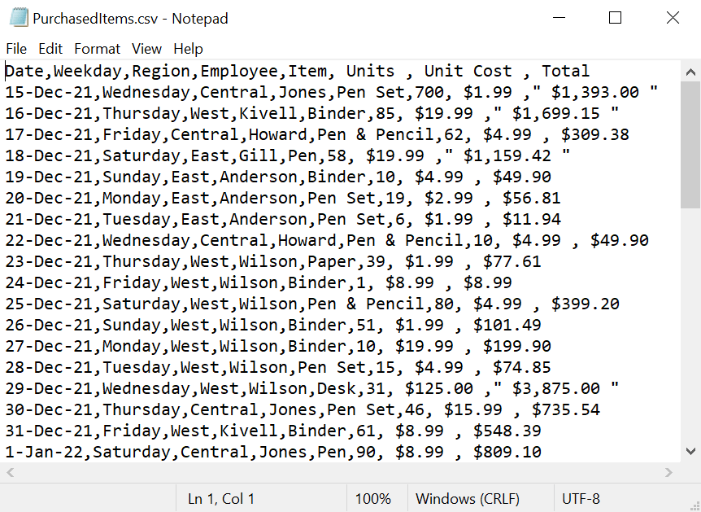

```python
from IPython.display import Image
Image("CSV2.png")
```

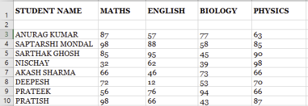

```python
from IPython.display import Image
Image("excel.png") # File path of excel.png if image is not placed in the same folder
```

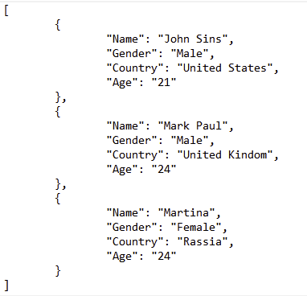

```python
from IPython.display import Image
Image("json.png") # JavaScript Object Notation
```

## Pre-requisites Packages

For loading the data from the APIs or websites you will also require the requests package which can be downloaded as follows:

- pip install pandas
- pip install requests
- pip install xlrd #to read data from excel sheet
- import sqlite3 as sql
- pip install mysql-connector
- import requests
- pip install pandas_datareader #Accessing financial data using pandas_datareader

```python
import pandas as pd
```

## Reading Data from Excel Files

```python
# excel absolute file path
excel_file = 'iris.xls' # no file path as it is placed in the same folder of notebook

# read data from an excel file
iris_data = pd.read_excel(excel_file, sheet_name='Data') # excel_file

#iris_data = pd.read_excel('iris.xls', sheet_name='Data') # excel_file

# to read csv file:--> pd.read_csv("")

# check the first few rows of data loaded from Excel
#iris_data.tail(10)
iris_data.head()
```

|  | Species_No | Petal_width | Petal_length | Sepal_width | Sepal_length | Species_name |
| --- | --- | --- | --- | --- | --- | --- |
| 0 | 1 | 0.2 | 1.4 | 3.5 | 5.1 | Setosa |
| 1 | 1 | 0.2 | 1.4 | 3.0 | 4.9 | Setosa |
| 2 | 1 | 0.2 | 1.3 | 3.2 | 4.7 | Setosa |
| 3 | 1 | 0.2 | 1.5 | 3.1 | 4.6 | Setosa |
| 4 | 1 | 0.2 | 1.4 | 3.6 | 5.0 | Setosa |

### Other arguments of the read_excel() method you might want to use are:

- header: Row (0-indexed) to use for the column labels. By default, it is inferred, but you can set it to None if there's no header.
- names: This is a list corresponding to the column names. Use this if you want to override or set column names.
- usecols: A list of columns or column range (e.g., 'A:D') to import from the Excel file.
- dtype: Dict of column name to data type. If not provided, pandas will try to infer the data type.

```python
iris_data = pd.read_excel(excel_file)
iris_data
```

|  | Species_No | Petal_width | Petal_length | Sepal_width | Sepal_length | Species_name |
| --- | --- | --- | --- | --- | --- | --- |
| 0 | 1 | 0.2 | 1.4 | 3.5 | 5.1 | Setosa |
| 1 | 1 | 0.2 | 1.4 | 3.0 | 4.9 | Setosa |
| 2 | 1 | 0.2 | 1.3 | 3.2 | 4.7 | Setosa |
| 3 | 1 | 0.2 | 1.5 | 3.1 | 4.6 | Setosa |
| 4 | 1 | 0.2 | 1.4 | 3.6 | 5.0 | Setosa |
| ... | ... | ... | ... | ... | ... | ... |
| 145 | 3 | 2.3 | 5.2 | 3.0 | 6.7 | Verginica |
| 146 | 3 | 1.9 | 5.0 | 2.5 | 6.3 | Verginica |
| 147 | 3 | 2.0 | 5.2 | 3.0 | 6.5 | Verginica |
| 148 | 3 | 2.3 | 5.4 | 3.4 | 6.2 | Verginica |
| 149 | 3 | 1.8 | 5.1 | 3.0 | 5.9 | Verginica |

150 rows × 6 columns

```python
iris_data = pd.read_excel(excel_file, header = 1)
iris_data
```

|  | 1 | 0.2 | 1.4 | 3.5 | 5.1 | Setosa |
| --- | --- | --- | --- | --- | --- | --- |
| 0 | 1 | 0.2 | 1.4 | 3.0 | 4.9 | Setosa |
| 1 | 1 | 0.2 | 1.3 | 3.2 | 4.7 | Setosa |
| 2 | 1 | 0.2 | 1.5 | 3.1 | 4.6 | Setosa |
| 3 | 1 | 0.2 | 1.4 | 3.6 | 5.0 | Setosa |
| 4 | 1 | 0.4 | 1.7 | 3.9 | 5.4 | Setosa |
| 5 | 1 | 0.3 | 1.4 | 3.4 | 4.6 | Setosa |
| 6 | 1 | 0.2 | 1.5 | 3.4 | 5.0 | Setosa |
| 7 | 1 | 0.2 | 1.4 | 2.9 | 4.4 | Setosa |
| 8 | 1 | 0.1 | 1.5 | 3.1 | 4.9 | Setosa |
| 9 | 1 | 0.2 | 1.5 | 3.7 | 5.4 | Setosa |
| 10 | 1 | 0.2 | 1.6 | 3.4 | 4.8 | Setosa |
| 11 | 1 | 0.1 | 1.4 | 3.0 | 4.8 | Setosa |
| 12 | 1 | 0.1 | 1.1 | 3.0 | 4.3 | Setosa |
| 13 | 1 | 0.2 | 1.2 | 4.0 | 5.8 | Setosa |
| 14 | 1 | 0.4 | 1.5 | 4.4 | 5.7 | Setosa |
| 15 | 1 | 0.4 | 1.3 | 3.9 | 5.4 | Setosa |
| 16 | 1 | 0.3 | 1.4 | 3.5 | 5.1 | Setosa |
| 17 | 1 | 0.3 | 1.7 | 3.8 | 5.7 | Setosa |
| 18 | 1 | 0.3 | 1.5 | 3.8 | 5.1 | Setosa |
| 19 | 1 | 0.2 | 1.7 | 3.4 | 5.4 | Setosa |
| 20 | 1 | 0.4 | 1.5 | 3.7 | 5.1 | Setosa |
| 21 | 1 | 0.2 | 1.0 | 3.6 | 4.6 | Setosa |
| 22 | 1 | 0.5 | 1.7 | 3.3 | 5.1 | Setosa |
| 23 | 1 | 0.2 | 1.9 | 3.4 | 4.8 | Setosa |
| 24 | 1 | 0.2 | 1.6 | 3.0 | 5.0 | Setosa |
| 25 | 1 | 0.4 | 1.6 | 3.4 | 5.0 | Setosa |
| 26 | 1 | 0.2 | 1.5 | 3.5 | 5.2 | Setosa |
| 27 | 1 | 0.2 | 1.4 | 3.4 | 5.2 | Setosa |
| 28 | 1 | 0.2 | 1.6 | 3.2 | 4.7 | Setosa |
| 29 | 1 | 0.2 | 1.6 | 3.1 | 4.8 | Setosa |

[output cut: 119 more lines]

```python
# use the names parameter to specify the column names explicitly
cols = ['Species_No', 'Petal_width', 'Petal_length', 'Sepal_width', 'Sepal_length', 'Species_name']
df = pd.read_excel('Iris.xls', header=1, names=cols)
df
```

|  | Species_No | Petal_width | Petal_length | Sepal_width | Sepal_length | Species_name |
| --- | --- | --- | --- | --- | --- | --- |
| 0 | 1 | 0.2 | 1.4 | 3.0 | 4.9 | Setosa |
| 1 | 1 | 0.2 | 1.3 | 3.2 | 4.7 | Setosa |
| 2 | 1 | 0.2 | 1.5 | 3.1 | 4.6 | Setosa |
| 3 | 1 | 0.2 | 1.4 | 3.6 | 5.0 | Setosa |
| 4 | 1 | 0.4 | 1.7 | 3.9 | 5.4 | Setosa |
| ... | ... | ... | ... | ... | ... | ... |
| 144 | 3 | 2.3 | 5.2 | 3.0 | 6.7 | Verginica |
| 145 | 3 | 1.9 | 5.0 | 2.5 | 6.3 | Verginica |
| 146 | 3 | 2.0 | 5.2 | 3.0 | 6.5 | Verginica |
| 147 | 3 | 2.3 | 5.4 | 3.4 | 6.2 | Verginica |
| 148 | 3 | 1.8 | 5.1 | 3.0 | 5.9 | Verginica |

149 rows × 6 columns

```python
# skiprows parameter to skip the header rows and read the data starting from a specific row.
df = pd.read_excel('Iris.xls', skiprows=[0, 1, 2], header=None)
df
```

|  | 0 | 1 | 2 | 3 | 4 | 5 |
| --- | --- | --- | --- | --- | --- | --- |
| 0 | 1 | 0.2 | 1.3 | 3.2 | 4.7 | Setosa |
| 1 | 1 | 0.2 | 1.5 | 3.1 | 4.6 | Setosa |
| 2 | 1 | 0.2 | 1.4 | 3.6 | 5.0 | Setosa |
| 3 | 1 | 0.4 | 1.7 | 3.9 | 5.4 | Setosa |
| 4 | 1 | 0.3 | 1.4 | 3.4 | 4.6 | Setosa |
| ... | ... | ... | ... | ... | ... | ... |
| 143 | 3 | 2.3 | 5.2 | 3.0 | 6.7 | Verginica |
| 144 | 3 | 1.9 | 5.0 | 2.5 | 6.3 | Verginica |
| 145 | 3 | 2.0 | 5.2 | 3.0 | 6.5 | Verginica |
| 146 | 3 | 2.3 | 5.4 | 3.4 | 6.2 | Verginica |
| 147 | 3 | 1.8 | 5.1 | 3.0 | 5.9 | Verginica |

148 rows × 6 columns

```python
#specify that all rows should be shown
pd.set_option('display.max_rows', None)
df
```

|  | 0 | 1 | 2 | 3 | 4 | 5 |
| --- | --- | --- | --- | --- | --- | --- |
| 0 | 1 | 0.2 | 1.3 | 3.2 | 4.7 | Setosa |
| 1 | 1 | 0.2 | 1.5 | 3.1 | 4.6 | Setosa |
| 2 | 1 | 0.2 | 1.4 | 3.6 | 5.0 | Setosa |
| 3 | 1 | 0.4 | 1.7 | 3.9 | 5.4 | Setosa |
| 4 | 1 | 0.3 | 1.4 | 3.4 | 4.6 | Setosa |
| 5 | 1 | 0.2 | 1.5 | 3.4 | 5.0 | Setosa |
| 6 | 1 | 0.2 | 1.4 | 2.9 | 4.4 | Setosa |
| 7 | 1 | 0.1 | 1.5 | 3.1 | 4.9 | Setosa |
| 8 | 1 | 0.2 | 1.5 | 3.7 | 5.4 | Setosa |
| 9 | 1 | 0.2 | 1.6 | 3.4 | 4.8 | Setosa |
| 10 | 1 | 0.1 | 1.4 | 3.0 | 4.8 | Setosa |
| 11 | 1 | 0.1 | 1.1 | 3.0 | 4.3 | Setosa |
| 12 | 1 | 0.2 | 1.2 | 4.0 | 5.8 | Setosa |
| 13 | 1 | 0.4 | 1.5 | 4.4 | 5.7 | Setosa |
| 14 | 1 | 0.4 | 1.3 | 3.9 | 5.4 | Setosa |
| 15 | 1 | 0.3 | 1.4 | 3.5 | 5.1 | Setosa |
| 16 | 1 | 0.3 | 1.7 | 3.8 | 5.7 | Setosa |
| 17 | 1 | 0.3 | 1.5 | 3.8 | 5.1 | Setosa |
| 18 | 1 | 0.2 | 1.7 | 3.4 | 5.4 | Setosa |
| 19 | 1 | 0.4 | 1.5 | 3.7 | 5.1 | Setosa |
| 20 | 1 | 0.2 | 1.0 | 3.6 | 4.6 | Setosa |
| 21 | 1 | 0.5 | 1.7 | 3.3 | 5.1 | Setosa |
| 22 | 1 | 0.2 | 1.9 | 3.4 | 4.8 | Setosa |
| 23 | 1 | 0.2 | 1.6 | 3.0 | 5.0 | Setosa |
| 24 | 1 | 0.4 | 1.6 | 3.4 | 5.0 | Setosa |
| 25 | 1 | 0.2 | 1.5 | 3.5 | 5.2 | Setosa |
| 26 | 1 | 0.2 | 1.4 | 3.4 | 5.2 | Setosa |
| 27 | 1 | 0.2 | 1.6 | 3.2 | 4.7 | Setosa |
| 28 | 1 | 0.2 | 1.6 | 3.1 | 4.8 | Setosa |
| 29 | 1 | 0.4 | 1.5 | 3.4 | 5.4 | Setosa |

[output cut: 118 more lines]

# Reading Data from CSV Files

```python
# CSV files are mainly used for storing relational data and are quick and easy to use with Python and Jupyter.
# Pandas provides the read_csv() function that can load the data in any environment and provides features to analyze and visualize the loaded data

# csv file path
csv_file = 'Iris.csv'
```

```python
# load data from the CSV file
iris_csv_data = pd.read_csv('Iris.csv')
```

```python
# check the first few rows of data loaded from CSV
iris_csv_data.head()
```

|  | sepal.length | sepal.width | petal.length | petal.width | variety |
| --- | --- | --- | --- | --- | --- |
| 0 | 5.1 | 3.5 | 1.4 | 0.2 | Setosa |
| 1 | 4.9 | 3.0 | 1.4 | 0.2 | Setosa |
| 2 | 4.7 | 3.2 | 1.3 | 0.2 | Setosa |
| 3 | 4.6 | 3.1 | 1.5 | 0.2 | Setosa |
| 4 | 5.0 | 3.6 | 1.4 | 0.2 | Setosa |

```python
# The read_csv() function also supports different arguments to:

# Load specific columns:

# Syntax: df = pd.read_csv('filename.csv', usecols=['column1', 'column2'])
df = pd.read_csv('Iris.csv', usecols=['sepal.length', 'sepal.width', 'variety'])
df
```

|  | sepal.length | sepal.width | variety |
| --- | --- | --- | --- |
| 0 | 5.1 | 3.5 | Setosa |
| 1 | 4.9 | 3.0 | Setosa |
| 2 | 4.7 | 3.2 | Setosa |
| 3 | 4.6 | 3.1 | Setosa |
| 4 | 5.0 | 3.6 | Setosa |
| 5 | 5.4 | 3.9 | Setosa |
| 6 | 4.6 | 3.4 | Setosa |
| 7 | 5.0 | 3.4 | Setosa |
| 8 | 4.4 | 2.9 | Setosa |
| 9 | 4.9 | 3.1 | Setosa |
| 10 | 5.4 | 3.7 | Setosa |
| 11 | 4.8 | 3.4 | Setosa |
| 12 | 4.8 | 3.0 | Setosa |
| 13 | 4.3 | 3.0 | Setosa |
| 14 | 5.8 | 4.0 | Setosa |
| 15 | 5.7 | 4.4 | Setosa |
| 16 | 5.4 | 3.9 | Setosa |
| 17 | 5.1 | 3.5 | Setosa |
| 18 | 5.7 | 3.8 | Setosa |
| 19 | 5.1 | 3.8 | Setosa |
| 20 | 5.4 | 3.4 | Setosa |
| 21 | 5.1 | 3.7 | Setosa |
| 22 | 4.6 | 3.6 | Setosa |
| 23 | 5.1 | 3.3 | Setosa |
| 24 | 4.8 | 3.4 | Setosa |
| 25 | 5.0 | 3.0 | Setosa |
| 26 | 5.0 | 3.4 | Setosa |
| 27 | 5.2 | 3.5 | Setosa |
| 28 | 5.2 | 3.4 | Setosa |
| 29 | 4.7 | 3.2 | Setosa |

[output cut: 120 more lines]

```python
#Skip erroneous rows:

# Syntax: df = pd.read_csv('filename.csv', error_bad_lines=False)
df = pd.read_csv('Iris.csv', on_bad_lines = "skip")
df
```

[output not shown]

```python
#Break files into chunks:
chunk_iter = pd.read_csv('Iris.csv', chunksize=10)
chunk_iter
```

```
<pandas.io.parsers.readers.TextFileReader at 0x12c080490>
```

# Reading Data from JSON Files

- JSON is a simple, lightweight, and widely used data format that stores data in human-readable format.
- It uses key-value pairs where each key is a string that uniquely identifies a value, which can be a string, number, boolean, array, or another JSON object.
- This format is commonly used for configuration files, responses from APIs, and data storage in various applications and is well suited for storing small-size dataset features.

Pandas provide the **read_json()** method that helps you load the JSON files into a Dataframe.

An example to load the iris.json file using pandas will look like this:

```python
# JSON file path
json_file = 'Iris.json'
```

```python
# load data from the JSON file
iris_json_data = pd.read_json(json_file)
```

```python
# check the first 5 rows of data loaded from JSON
iris_json_data.head()
```

|  | sepalLength | sepalWidth | petalLength | petalWidth | species |
| --- | --- | --- | --- | --- | --- |
| 0 | 5.1 | 3.5 | 1.4 | 0.2 | setosa |
| 1 | 4.9 | 3.0 | 1.4 | 0.2 | setosa |
| 2 | 4.7 | 3.2 | 1.3 | 0.2 | setosa |
| 3 | 4.6 | 3.1 | 1.5 | 0.2 | setosa |
| 4 | 5.0 | 3.6 | 1.4 | 0.2 | setosa |

[output not shown]

[ {"X": 1, "Y": 2},  
{"X": 3, "Y": 4},  
{"X": 5, "Y": 6} ]

## Pandas also supports file formats such as XML, HDF5, HTML, LaTeX, Fixed-Width txt files, and others.

Link [https://pandas.pydata.org/docs/user_guide/io.html]

# Accessing Data From Databases and Data Warehouses

- While file storage is good for small-size datasets, databases, and data warehouses are designed to hold almost any size of data.
- Most organizations store their large amount of business-specific data in local or cloud databases such as MySQL, MongoDB, or PostgreSQL.
- These databases are normally created, accessed, and managed using the Structured Query Language (SQL) for different business purposes.
- Python provides a lot of connectors to access the data from different types of databases using the same SQL queries.
- Pandas play a key role as you can read the queried data as a dataframe and perform multiple operations of your choice.